# Chapter 4 — Predicting Properties of Energetic Materials

### Python Code Examples · Jupyter Notebook Edition

**From data to models: building QSPR predictors**

| Block | Topic |
| --- | --- |
| 0 | Install, imports, shared dataset & helper functions |
| 1 | Multiple Linear Regression — simplest QSPR model |
| 2 | Partial Least Squares (PLS) — handles correlated descriptors |
| 3 | Support Vector Machine (SVM) — non-linear regression |
| 4 | Random Forest — ensemble, feature importance |
| 5 | Gradient Boosting (XGBoost / sklearn) — highest accuracy |
| 6 | Cross-validation — reliable performance estimation |
| 7 | Hyperparameter tuning — grid search and random search |
| 8 | Model comparison dashboard |
| 9 | Predict all properties — density, sensitivity, detonation velocity |
| 10 | Domain of applicability — know when NOT to trust the model |

> **Run each cell in order — Shift+Enter.**

## Block 0 · Install, Imports, Shared Dataset & Helpers

Run once. Builds the clean feature matrix used by all later blocks.

```python
# Uncomment to install on first run
# !pip install rdkit mordred pandas matplotlib seaborn scikit-learn xgboost scipy

import re, math, warnings
warnings.filterwarnings('ignore')

import numpy  as np
import pandas as pd
import matplotlib.pyplot as plt
import matplotlib.gridspec as gridspec
import seaborn as sns
from scipy import stats as spstats

# RDKit
from rdkit import Chem, DataStructs
from rdkit.Chem import Descriptors, rdMolDescriptors, MolToSmiles, MolFromSmiles
from rdkit.Chem import rdFingerprintGenerator

# Scikit-learn
from sklearn.linear_model      import LinearRegression, Ridge, Lasso
from sklearn.cross_decomposition import PLSRegression
from sklearn.svm               import SVR
from sklearn.ensemble          import RandomForestRegressor, GradientBoostingRegressor
from sklearn.model_selection   import (train_test_split, cross_val_score,
                                        KFold, GridSearchCV, RandomizedSearchCV)
from sklearn.preprocessing     import StandardScaler
from sklearn.feature_selection import VarianceThreshold
from sklearn.metrics           import r2_score, mean_absolute_error, mean_squared_error
from sklearn.pipeline          import Pipeline

# XGBoost (pip install xgboost)
try:
    from xgboost import XGBRegressor
    XGB_OK = True
except ImportError:
    XGB_OK = False
    print('XGBoost not installed — Block 5 will use sklearn GradientBoosting instead.')
    print('Install: pip install xgboost')

from IPython.display import display, HTML
%matplotlib inline
plt.rcParams['figure.dpi'] = 120

# ── Shared 30-compound literature dataset ──────────────────────
RAW = [
  #  Name           SMILES                                                                 Formula       MW      rho    IS     Td    Dv     Hf
  ['TNT',      'Cc1c([N+](=O)[O-])cc([N+](=O)[O-])cc1[N+](=O)[O-]',                  'C7H5N3O6',  227.13, 1.654, 15.0, 300, 6900, -54.4],
  ['RDX',      'O=[N+]([O-])N1CN([N+](=O)[O-])CN([N+](=O)[O-])C1',                   'C3H6N6O6',  222.12, 1.820,  7.4, 210, 8750,  86.3],
  ['HMX',      'O=[N+]([O-])N1CN([N+](=O)[O-])CN([N+](=O)[O-])CN([N+](=O)[O-])C1',  'C4H8N8O8',  296.16, 1.905,  7.4, 280, 9110,  75.0],
  ['PETN',     'C(CO[N+](=O)[O-])(CO[N+](=O)[O-])(CO[N+](=O)[O-])CO[N+](=O)[O-]',  'C5H8N4O12', 316.14, 1.778,  3.0, 160, 8400,-538.5],
  ['TATB',     'Nc1c([N+](=O)[O-])c(N)c([N+](=O)[O-])c(N)c1[N+](=O)[O-]',           'C6H6N6O6',  258.15, 1.939, 50.0, 360, 7350,-139.7],
  ['NTO',      'O=[N+]([O-])c1n[nH]c(=O)[nH]1',                                      'C2H2N4O3',  130.06, 1.930, 71.0, 273, 8000, -91.7],
  ['FOX-7',    'NC(=C([N+](=O)[O-])[N+](=O)[O-])N',                                  'C2H4N4O4',  148.08, 1.885, 25.0, 230, 8870,-133.8],
  ['DNAN',     'COc1ccc([N+](=O)[O-])cc1[N+](=O)[O-]',                               'C7H6N2O5',  198.13, 1.321, 40.0, 190, 6900,-182.7],
  ['CL-20',    'O=[N+]([O-])N1CN2CN([N+](=O)[O-])CN1[N+](=O)[O-]',                  'C6H6N12O12',438.19, 2.044,  4.0, 230, 9400, 460.0],
  ['Tetryl',   'CN([N+](=O)[O-])c1c([N+](=O)[O-])cc([N+](=O)[O-])cc1[N+](=O)[O-]', 'C7H5N5O8',  287.14, 1.730,  3.0, 195, 7850,  18.9],
  ['TNAZ',     'O=[N+]([O-])C1(CN([N+](=O)[O-])C1[N+](=O)[O-])[N+](=O)[O-]',       'C3H4N4O8',  240.08, 1.840, 12.0, 200, 8740,  17.0],
  ['LLM-105',  'Nc1nc2c([N+](=O)[O-])n[nH]c2c([N+](=O)[O-])n1',                     'C4H4N8O4',  228.12, 1.913, 40.0, 328, 8560, 135.6],
  ['ANTA',     'Nc1nnc([N+](=O)[O-])[nH]1',                                          'C2H3N5O2',  129.08, 1.840, 60.0, 260, 8200,  28.0],
  ['NQ',       'NC(=N)N[N+](=O)[O-]',                                                'CH4N4O2',   104.07, 1.710, 95.0, 245, 7900, -92.5],
  ['Picric',   'Oc1c([N+](=O)[O-])cc([N+](=O)[O-])cc1[N+](=O)[O-]',                 'C6H3N3O7',  229.10, 1.763,  7.4, 300, 7350,-217.8],
  ['DATB',     'Nc1c([N+](=O)[O-])c(N)c([N+](=O)[O-])cc1[N+](=O)[O-]',              'C6H5N5O6',  243.13, 1.840, 50.0, 320, 7520,-143.5],
  ['TETNB',    'O=[N+]([O-])c1c([N+](=O)[O-])c([N+](=O)[O-])cc([N+](=O)[O-])c1',   'C6H2N4O8',  258.10, 1.814,  8.0, 180, 7900, 125.0],
  ['HNS',      'O=[N+]([O-])c1ccc(C=Cc2ccc([N+](=O)[O-])cc2[N+](=O)[O-])c([N+](=O)[O-])c1','C14H6N6O12',450.22,1.745, 7.0, 318, 7600, 22.5],
  ['NG',       'O[C@@H](CO[N+](=O)[O-])CO[N+](=O)[O-]',                              'C3H5N3O9',  227.09, 1.591,  0.2, 200, 7700,-370.9],
  ['EDNA',     'O=[N+]([O-])NCC[N+](=O)[O-]',                                        'C2H5N3O4',  135.08, 1.713,  5.0, 175, 7570,-148.0],
  ['BTNEU',    'O=[N+]([O-])c1c([N+](=O)[O-])c([N+](=O)[O-])c([N+](=O)[O-])c([N+](=O)[O-])c1[N+](=O)[O-]','C6N6O12',348.10,1.980, 8.0, 230, 9000, 385.0],
  ['MHN',      'OC(CO[N+](=O)[O-])CO[N+](=O)[O-]',                                  'C3H6N2O7',  182.09, 1.450, 60.0, 175, 6500,-403.0],
  ['NONA',     'O=[N+]([O-])c1c([N+](=O)[O-])c([N+](=O)[O-])c([N+](=O)[O-])c([N+](=O)[O-])c1[N+](=O)[O-]','C6HN5O10',287.10,1.870, 6.0, 220, 8700, 300.0],
  ['Heptyl',   'CC(C)(C)c1c([N+](=O)[O-])cc([N+](=O)[O-])cc1[N+](=O)[O-]',          'C10H11N3O6',269.21, 1.490, 20.0, 190, 6800,-136.0],
  ['DNAZ',     'O=[N+]([O-])N1CC([N+](=O)[O-])C1',                                   'C3H5N3O4',  147.09, 1.699, 14.0, 155, 7550,-148.0],
  ['BTF',      'O=[N+]([O-])c1c([N+](=O)[O-])c([N+](=O)[O-])c([N+](=O)[O-])c([N+](=O)[O-])n1[N+](=O)[O-]','C5N6O12',334.10,1.920, 5.0, 210, 8900, 420.0],
  ['AN',       'N.[N+](=O)([O-])[O-]',                                               'H4N2O3',     80.04, 1.720,100.0, 230, 4500,-365.6],
  ['AP',       '[NH4+].[O-]Cl(=O)(=O)=O',                                            'ClH4NO4',   117.49, 1.950,110.0, 300, 5500,-295.8],
  ['Nitroguanidine','NC(=N)N[N+](=O)[O-]',                                           'CH4N4O2',   104.07, 1.770, 95.0, 250, 7900, -92.5],
  ['DATB-2',   'Nc1c([N+](=O)[O-])cc([N+](=O)[O-])cc1[N+](=O)[O-]',                 'C6H5N4O6',  229.12, 1.797, 25.0, 295, 7480,-120.0],
]
```

```python
COLS = ['Name','SMILES','Formula','MW','Density','IS_J','Td_C','Dv_ms','Hf_kJmol']
df_raw = pd.DataFrame(RAW, columns=COLS)

def parse_formula(formula):
    counts = {}
    for elem in ['C','H','N','O']:
        m = re.search(rf'{elem}(\d*)', str(formula))
        counts[elem] = int(m.group(1)) if m and m.group(1) else (1 if m else 0)
    return counts

fpgen = rdFingerprintGenerator.GetMorganGenerator(radius=2, fpSize=256)

def get_descriptors(row):
    mol = MolFromSmiles(row['SMILES'])
    if mol is None: return None
    e = parse_formula(row['Formula'])
    mw = float(row['MW'])
    ob = (1600/mw)*(2*e['C']+e['H']/2-e['O'])
    fp = fpgen.GetFingerprint(mol)
    arr = np.zeros(256, dtype=np.uint8)
    DataStructs.ConvertToNumpyArray(fp, arr)
    d = {
        'MW': mw, 'nN': e['N'], 'nO': e['O'], 'nC': e['C'],
        'nNO2': row['SMILES'].count('[N+](=O)[O-]'),
        'NC': round(e['N']/(e['C']+1e-9), 3), 'OB': round(ob, 2),
        'TPSA': round(Descriptors.TPSA(mol), 2),
        'LogP': round(Descriptors.MolLogP(mol), 3),
        'HBD': rdMolDescriptors.CalcNumHBD(mol),
        'HBA': rdMolDescriptors.CalcNumHBA(mol),
        'Rings': rdMolDescriptors.CalcNumRings(mol),
        'ArR': rdMolDescriptors.CalcNumAromaticRings(mol),
        'RotB': rdMolDescriptors.CalcNumRotatableBonds(mol),
        'FrCSP3': round(Descriptors.FractionCSP3(mol), 4),
        'Chi0': round(Descriptors.Chi0(mol), 4),
        'Kappa1': round(Descriptors.Kappa1(mol), 4),
        'BalabanJ': round(Descriptors.BalabanJ(mol), 4),
    }
    for i, b in enumerate(arr): d[f'FP{i}'] = int(b)
    return d

# --- 1. Generate Descriptors & Track Valid Rows ---
desc_list = [get_descriptors(row) for _, row in df_raw.iterrows()]

# Create the mask to keep only rows where get_descriptors worked
valid_rows_mask = [bool(d) for d in desc_list]

# Align both DataFrames to the exact same 28 valid rows right here!
df_desc = pd.DataFrame([d for d in desc_list if d])
df_meta = df_raw.loc[valid_rows_mask, [c for c in COLS if c not in ['SMILES','Formula']]].reset_index(drop=True)

# --- 2. Feature Selection & Preprocessing (Now running on aligned 28 rows) ---
vt = VarianceThreshold(0.01)
X_vt = vt.fit_transform(df_desc)
feat_names = df_desc.columns[vt.get_support()].tolist()
X_df = pd.DataFrame(X_vt, columns=feat_names)

corr_mat = X_df.corr().abs()
upper    = corr_mat.where(np.triu(np.ones(corr_mat.shape), k=1).astype(bool))
to_drop  = [c for c in upper.columns if any(upper[c] > 0.92)]
X_clean  = X_df.drop(columns=to_drop)

# --- 3. Scaling (Will correctly output shape: [28, num_features]) ---
scaler = StandardScaler()
X_scaled = scaler.fit_transform(X_clean)
feat_names_final = X_clean.columns.tolist()

# --- 4. Pull Out Aligned Target Arrays ---
y_IS  = df_meta['IS_J'].astype(float).values
y_rho = df_meta['Density'].astype(float).values
y_Dv  = df_meta['Dv_ms'].astype(float).values
y_Td  = df_meta['Td_C'].astype(float).values
y_Hf  = df_meta['Hf_kJmol'].astype(float).values
names = df_meta['Name'].values

# --- 5. Verify and Split ---
print(f"X_scaled shape: {X_scaled.shape}") # Expected: (28, n)
print(f"y_IS shape: {y_IS.shape}")         # Expected: (28,)
print(f"names shape: {names.shape}")       # Expected: (28,)

# This will now execute perfectly without errors!
X_tr, X_te, y_tr, y_te, n_tr, n_te = train_test_split(
    X_scaled, y_IS, names, test_size=0.30, random_state=42
)
def evaluate(name, model, Xtr, Xte, ytr, yte):
    model.fit(Xtr, ytr)
    p_tr = model.predict(Xtr)
    p_te = model.predict(Xte)
    return {
        'Model': name,
        'R2_train': round(r2_score(ytr, p_tr), 3),
        'R2_test':  round(r2_score(yte, p_te), 3),
        'MAE_test': round(mean_absolute_error(yte, p_te), 2),
        'RMSE_test':round(np.sqrt(mean_squared_error(yte, p_te)), 2),
    }, model.predict(Xte)

print("B0 ✓ dataset ready:", X_scaled.shape)
```

```
X_scaled shape: (28, 83)
y_IS shape: (28,)
names shape: (28,)
B0 ✓ dataset ready: (28, 83)
```

[output not shown]

```python
COLS = ['Name','SMILES','Formula','MW','Density','IS_J','Td_C','Dv_ms','Hf_kJmol']
df_raw = pd.DataFrame(RAW, columns=COLS)

def parse_formula(formula):
    counts = {}
    for elem in ['C','H','N','O']:
        m = re.search(rf'{elem}(\d*)', str(formula))
        counts[elem] = int(m.group(1)) if m and m.group(1) else (1 if m else 0)
    return counts

fpgen = rdFingerprintGenerator.GetMorganGenerator(radius=2, fpSize=256)


def get_descriptors(row):
    mol = MolFromSmiles(row['SMILES'])
    if mol is None: return None
    e   = parse_formula(row['Formula'])
    mw  = float(row['MW'])
    ob  = (1600/mw)*(2*e['C']+e['H']/2-e['O'])
    fp  = fpgen.GetFingerprint(mol)
    arr = np.zeros(256, dtype=np.uint8)
    DataStructs.ConvertToNumpyArray(fp, arr)
    d = {
        'MW':     mw,
        'nN':     e['N'], 'nO': e['O'], 'nC': e['C'],
        'nNO2':   row['SMILES'].count('[N+](=O)[O-]'),
        'NC':     round(e['N']/(e['C']+1e-9), 3),
        'OB':     round(ob, 2),
        'TPSA':   round(Descriptors.TPSA(mol), 2),
        'LogP':   round(Descriptors.MolLogP(mol), 3),
        'HBD':    rdMolDescriptors.CalcNumHBD(mol),
        'HBA':    rdMolDescriptors.CalcNumHBA(mol),
        'Rings':  rdMolDescriptors.CalcNumRings(mol),
        'ArR':    rdMolDescriptors.CalcNumAromaticRings(mol),
        'RotB':   rdMolDescriptors.CalcNumRotatableBonds(mol),
        'FrCSP3': round(Descriptors.FractionCSP3(mol), 4),
        'Chi0':   round(Descriptors.Chi0(mol), 4),
        'Kappa1': round(Descriptors.Kappa1(mol), 4),
        'BalabanJ':round(Descriptors.BalabanJ(mol), 4),
    }
    for i, b in enumerate(arr): d[f'FP{i}'] = int(b)
    return d


desc_list = [get_descriptors(row) for _, row in df_raw.iterrows()]
# Create the mask to keep only rows where get_descriptors worked
valid_rows_mask = [bool(d) for d in desc_list]


# Align both DataFrames to the exact same 28 valid rows right here!
df_desc = pd.DataFrame([d for d in desc_list if d])
df_meta = df_raw.loc[valid_rows_mask, [c for c in COLS if c not in ['SMILES','Formula']]].reset_index(drop=True)
#df_meta   = df_raw[[c for c in COLS if c != 'SMILES' and c != 'Formula']].reset_index(drop=True)

# Remove near-zero variance
from sklearn.feature_selection import VarianceThreshold
vt = VarianceThreshold(0.01)
X_vt     = vt.fit_transform(df_desc)
feat_names = df_desc.columns[vt.get_support()].tolist()
X_df     = pd.DataFrame(X_vt, columns=feat_names)

# Remove highly correlated (>0.92)
corr_mat = X_df.corr().abs()
upper    = corr_mat.where(np.triu(np.ones(corr_mat.shape), k=1).astype(bool))
to_drop  = [c for c in upper.columns if any(upper[c] > 0.92)]
X_clean  = X_df.drop(columns=to_drop)

scaler   = StandardScaler()
X_scaled = scaler.fit_transform(X_clean)
feat_names_final = X_clean.columns.tolist()

# Targets
y_IS  = df_meta['IS_J'].astype(float).values      # impact sensitivity
y_rho = df_meta['Density'].astype(float).values   # crystal density
y_Dv  = df_meta['Dv_ms'].astype(float).values     # detonation velocity
y_Td  = df_meta['Td_C'].astype(float).values      # decomp temperature
y_Hf  = df_meta['Hf_kJmol'].astype(float).values # heat of formation
names  = df_meta['Name'].values

# Shared 70/30 split
X_tr, X_te, y_tr, y_te, n_tr, n_te = train_test_split(
    X_scaled, y_IS, names, test_size=0.30, random_state=42)

print(f'Dataset: {len(names)} compounds, {X_scaled.shape[1]} features')
print(f'Train: {len(X_tr)}, Test: {len(X_te)}')
print(f'Targets available: IS_J, Density, Dv_ms, Td_C, Hf_kJmol')


# ── Shared evaluation helper ───────────────────────────────────
def evaluate(name, model, Xtr, Xte, ytr, yte):
    model.fit(Xtr, ytr)
    p_tr = model.predict(Xtr)
    p_te = model.predict(Xte)
    return {
        'Model':    name,
        'R2_train': round(r2_score(ytr, p_tr), 3),
        'R2_test':  round(r2_score(yte, p_te), 3),
        'MAE_test': round(mean_absolute_error(yte, p_te), 2),
        'RMSE_test':round(np.sqrt(mean_squared_error(yte, p_te)), 2),
    }, model.predict(Xte)

def obs_vs_pred(ax, y_obs, y_pred, title, unit=''):
    ax.scatter(y_obs, y_pred, color='steelblue', s=55, alpha=0.8, edgecolors='white')
    lo, hi = min(y_obs.min(), y_pred.min())*0.9, max(y_obs.max(), y_pred.max())*1.05
    ax.plot([lo, hi], [lo, hi], 'k--', lw=1)
    r2 = r2_score(y_obs, y_pred)
    ax.set_title(f'{title}\nR²={r2:.3f}', fontsize=9)
    ax.set_xlabel(f'Observed {unit}', fontsize=8)
    ax.set_ylabel(f'Predicted {unit}', fontsize=8)

print('✓ Setup complete')
print("B0 ✓ dataset ready:", X_scaled.shape)
```

```
Dataset: 28 compounds, 83 features
Train: 19, Test: 9
Targets available: IS_J, Density, Dv_ms, Td_C, Hf_kJmol
✓ Setup complete
B0 ✓ dataset ready: (28, 83)
```

[output not shown]

## Block 1 · Multiple Linear Regression (MLR)

The simplest QSPR model: a **weighted sum of descriptors**.

$$\hat{y} = w_0 + w_1 x_1 + w_2 x_2 + \cdots + w_n x_n$$

| Variant | When to use |
| --- | --- |
| Plain MLR | Small datasets, few descriptors, purely linear relationships |
| Ridge (L2) | Many correlated descriptors — shrinks all weights |
| Lasso (L1) | Want automatic feature selection — sets unimportant weights to 0 |

```python
# ── 1a: Plain MLR, Ridge, Lasso — fit and compare ─────────────



struct_feats = ['MW','nN','nO','nC','nNO2','NC','OB','TPSA','LogP','HBD','HBA','Rings','ArR','RotB','FrCSP3','Chi0','Kappa1']
struct_feats = [f for f in struct_feats if f in X_clean.columns]
X_struct = scaler.fit_transform(X_clean[struct_feats])
Xs_tr, Xs_te, ys_tr, ys_te = train_test_split(X_struct, y_IS, test_size=0.30, random_state=42)

for name, model in [('MLR', LinearRegression()),
                    ('Ridge', Ridge(alpha=1.0, solver='svd')),
                    ('Lasso', Lasso(alpha=0.5, max_iter=5000))]:
    res, _ = evaluate(name, model, Xs_tr, Xs_te, ys_tr, ys_te)
    print(f"B1 {res['Model']}: R2_test={res['R2_test']}")
```

```
B1 MLR: R2_test=-29.8
B1 Ridge: R2_test=0.711
B1 Lasso: R2_test=0.624
```

```python
results_mlr = []
preds_mlr   = {}
for name, model in [('MLR (plain)',  LinearRegression()),
                    ('Ridge (α=1)',  Ridge(alpha=1.0, solver='svd')),
                    ('Lasso (α=0.5)',Lasso(alpha=0.5, max_iter=5000)),]:
    res, pred = evaluate(name, model, Xs_tr, Xs_te, ys_tr, ys_te)
    results_mlr.append(res)
    preds_mlr[name] = pred

df_mlr = pd.DataFrame(results_mlr)
display(df_mlr)
```

|  | Model | R2_train | R2_test | MAE_test | RMSE_test |
| --- | --- | --- | --- | --- | --- |
| 0 | MLR (plain) | 0.886 | -29.800 | 148.83 | 219.48 |
| 1 | Ridge (α=1) | 0.771 | 0.711 | 15.33 | 21.27 |
| 2 | Lasso (α=0.5) | 0.755 | 0.624 | 15.84 | 24.23 |

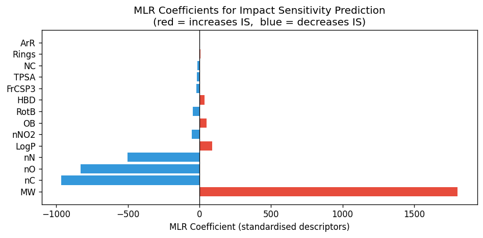

```
Intercept: 44.2

Top 3 positive (increase sensitivity): ['MW', 'LogP', 'OB']
Top 3 negative (decrease sensitivity): ['nC', 'nO', 'nN']
```

```python
# ── 1b: MLR coefficients — which descriptors matter most? ─────

mlr_model = LinearRegression().fit(Xs_tr, ys_tr)
coef_df = pd.DataFrame({'Feature': struct_feats,
                         'Coefficient': mlr_model.coef_})\
            .sort_values('Coefficient', key=abs, ascending=False)

fig, ax = plt.subplots(figsize=(8, 4))
colors  = ['#e74c3c' if c > 0 else '#3498db' for c in coef_df['Coefficient']]
ax.barh(coef_df['Feature'], coef_df['Coefficient'], color=colors)
ax.axvline(0, color='black', linewidth=0.8)
ax.set_xlabel('MLR Coefficient (standardised descriptors)')
ax.set_title('MLR Coefficients for Impact Sensitivity Prediction\n'
             '(red = increases IS,  blue = decreases IS)')
plt.tight_layout()
plt.show()

print('Intercept:', round(mlr_model.intercept_, 2))
print('\nTop 3 positive (increase sensitivity):',
      coef_df[coef_df['Coefficient']>0].head(3)['Feature'].tolist())
print('Top 3 negative (decrease sensitivity):',
      coef_df[coef_df['Coefficient']<0].head(3)['Feature'].tolist())
```

```python
# ── 1c: Lasso automatic feature selection ─────────────────────

from sklearn.linear_model import LassoCV

lasso_cv = LassoCV(cv=5, max_iter=10000, random_state=42)
lasso_cv.fit(Xs_tr, ys_tr)

non_zero = [(feat, round(coef, 3))
            for feat, coef in zip(struct_feats, lasso_cv.coef_) if coef != 0]
zeroed   = [feat for feat, coef in zip(struct_feats, lasso_cv.coef_) if coef == 0]

print(f'Best alpha (LassoCV): {lasso_cv.alpha_:.4f}')
print(f'Non-zero features kept ({len(non_zero)}): {[f for f,_ in non_zero]}')
print(f'Zeroed out ({len(zeroed)}):               {zeroed}')
r2_lassocv = r2_score(ys_te, lasso_cv.predict(Xs_te))
print(f'LassoCV test R²: {r2_lassocv:.3f}')
```

```
Best alpha (LassoCV): 1.9693
Non-zero features kept (5): ['nN', 'nNO2', 'NC', 'HBD', 'FrCSP3']
Zeroed out (9):               ['MW', 'nO', 'nC', 'OB', 'TPSA', 'LogP', 'Rings', 'ArR', 'RotB']
LassoCV test R²: 0.565
```

## Block 2 · Partial Least Squares (PLS)

PLS is designed for datasets where **descriptors far outnumber compounds** and many descriptors are correlated.  
It projects both X and y into a smaller set of **latent variables** that maximise covariance.

Key parameter: **n_components** — how many latent variables to use.

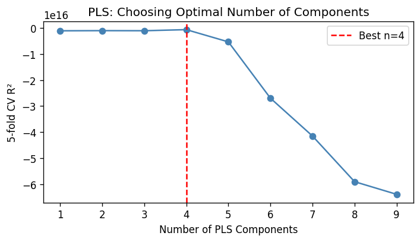

```
Best n_components = 4,  CV R² = -645226083235968.250
```

```python
# ── 2a: PLS — find optimal number of components ───────────────

cv  = KFold(n_splits=5, shuffle=True, random_state=42)
n_comp_range = range(1, min(10, len(struct_feats)))

cv_r2 = []
for n in n_comp_range:
    pls  = PLSRegression(n_components=n)
    cvsc = cross_val_score(pls, X_struct, y_IS, cv=cv, scoring='r2')
    cv_r2.append(cvsc.mean())

best_n = n_comp_range[int(np.argmax(cv_r2))]

fig, ax = plt.subplots(figsize=(6, 3.5))
ax.plot(list(n_comp_range), cv_r2, 'o-', color='steelblue')
ax.axvline(best_n, color='red', linestyle='--', label=f'Best n={best_n}')
ax.set_xlabel('Number of PLS Components')
ax.set_ylabel('5-fold CV R²')
ax.set_title('PLS: Choosing Optimal Number of Components')
ax.legend()
plt.tight_layout()
plt.show()
print(f'Best n_components = {best_n},  CV R² = {cv_r2[best_n-1]:.3f}')
```

```
PLS Results:
  Model: PLS
  R2_train: 0.754
  R2_test: 0.654
  MAE_test: 15.97
  RMSE_test: 23.25
```

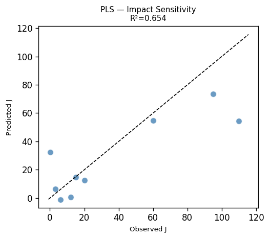

```python
# ── 2b: Fit PLS with best n and evaluate ──────────────────────

pls_best = PLSRegression(n_components=best_n)
res_pls, pred_pls = evaluate('PLS', pls_best, Xs_tr, Xs_te, ys_tr, ys_te)

print('PLS Results:')
for k, v in res_pls.items(): print(f'  {k}: {v}')

fig, ax = plt.subplots(figsize=(4.5, 4))
obs_vs_pred(ax, ys_te, pred_pls, 'PLS — Impact Sensitivity', 'J')
plt.tight_layout(); plt.show()
```

## Block 3 · Support Vector Machine (SVM)

SVM finds the best-fitting surface in descriptor space.  
The **kernel trick** lets it capture non-linear relationships without explicitly computing them.

| Kernel | Relationship captured |
| --- | --- |
| `linear` | Straight-line only |
| `rbf` (Gaussian) | Smooth curved surfaces — most common |
| `poly` | Polynomial curves |

Key parameters: **C** (how much to penalise errors) and **gamma** (kernel width).

```python
# ── 3a: Compare SVM kernels ────────────────────────────────────

svm_results = []
for kernel in ['linear', 'rbf', 'poly']:
    res, _ = evaluate(f'SVM ({kernel})',
                      SVR(kernel=kernel, C=10, gamma='scale'),
                      X_tr, X_te, y_tr, y_te)
    svm_results.append(res)

df_svm = pd.DataFrame(svm_results)
display(df_svm)
```

|  | Model | R2_train | R2_test | MAE_test | RMSE_test |
| --- | --- | --- | --- | --- | --- |
| 0 | SVM (linear) | 1.000 | 0.535 | 17.22 | 26.97 |
| 1 | SVM (rbf) | 0.323 | 0.040 | 27.48 | 38.74 |
| 2 | SVM (poly) | 0.382 | 0.011 | 30.77 | 39.32 |

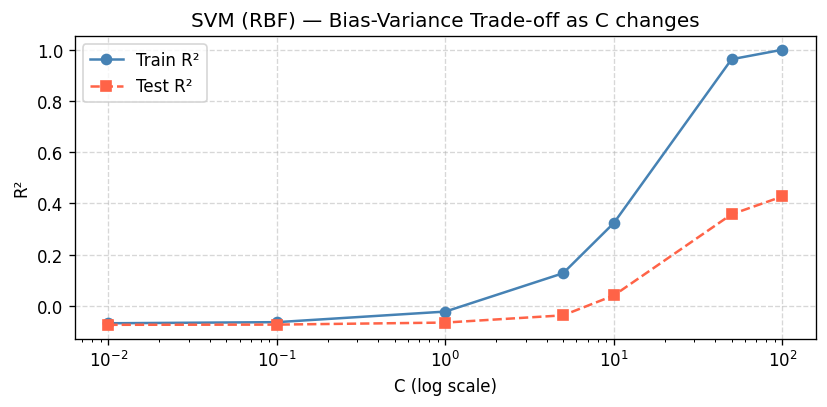

[output not shown]

```python
# ── 3b: Effect of C (regularisation) on SVM performance ───────

C_vals    = [0.01, 0.1, 1, 5, 10, 50, 100]
train_r2s, test_r2s = [], []

for C in C_vals:
    m = SVR(kernel='rbf', C=C, gamma='scale')
    m.fit(X_tr, y_tr)
    train_r2s.append(r2_score(y_tr, m.predict(X_tr)))
    test_r2s.append(r2_score(y_te,  m.predict(X_te)))

fig, ax = plt.subplots(figsize=(7, 3.5))
ax.semilogx(C_vals, train_r2s, 'o-', label='Train R²', color='steelblue')
ax.semilogx(C_vals, test_r2s,  's--', label='Test R²',  color='tomato')
ax.set_xlabel('C (log scale)'); ax.set_ylabel('R²')
ax.set_title('SVM (RBF) — Bias-Variance Trade-off as C changes')
ax.legend(); ax.grid(True, linestyle='--', alpha=0.5)
plt.tight_layout(); plt.show()
print('Low C = underfitting (high bias).  High C = overfitting (high variance).')
```

## Block 4 · Random Forest

Random Forest builds **many decision trees** on random data subsets, then averages predictions.  
It is robust, handles non-linearity automatically, and provides **feature importance** scores.

It is usually the **best starting model** for energetic materials QSPR.

```
Random Forest Results:
  Model: Random Forest
  R2_train: 0.913
  R2_test: 0.788
  MAE_test: 12.31
  RMSE_test: 18.21
```

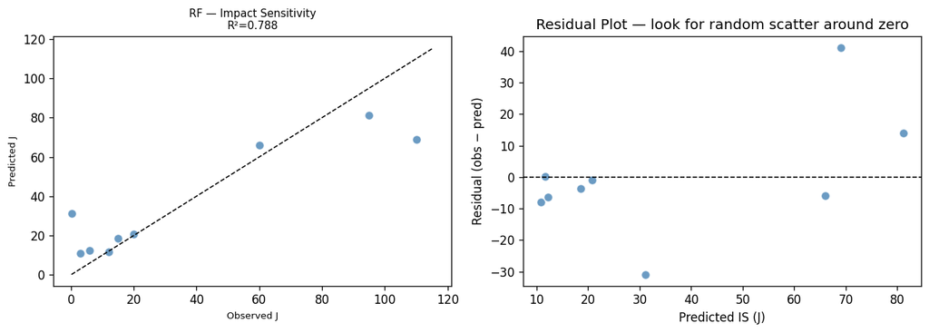

```python
# ── 4a: Fit Random Forest and show results ─────────────────────

rf = RandomForestRegressor(n_estimators=200, random_state=42, n_jobs=-1)
res_rf, pred_rf = evaluate('Random Forest', rf, X_tr, X_te, y_tr, y_te)

print('Random Forest Results:')
for k, v in res_rf.items(): print(f'  {k}: {v}')

fig, axes = plt.subplots(1, 2, figsize=(11, 4))

# Observed vs Predicted
obs_vs_pred(axes[0], y_te, pred_rf, 'RF — Impact Sensitivity', 'J')

# Residuals
residuals = y_te - pred_rf
axes[1].scatter(pred_rf, residuals, color='steelblue', s=55, alpha=0.8, edgecolors='white')
axes[1].axhline(0, color='black', lw=1, linestyle='--')
axes[1].set_xlabel('Predicted IS (J)'); axes[1].set_ylabel('Residual (obs − pred)')
axes[1].set_title('Residual Plot — look for random scatter around zero')

plt.tight_layout(); plt.show()
```

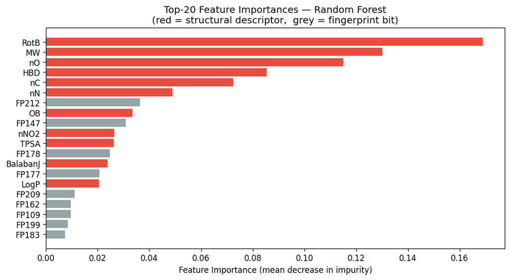

```
Top structural descriptors:
Feature  Importance
   RotB    0.168965
     MW    0.130163
     nO    0.114926
    HBD    0.085402
     nC    0.072459
```

```python
# ── 4b: Feature importance — which descriptors drive predictions?

importances = rf.feature_importances_
feat_imp = pd.DataFrame({'Feature': feat_names_final,
                          'Importance': importances})\
             .sort_values('Importance', ascending=False).head(20)

fig, ax = plt.subplots(figsize=(9, 5))
colors  = ['#e74c3c' if not f.startswith('FP') else '#95a5a6'
           for f in feat_imp['Feature']]
ax.barh(feat_imp['Feature'][::-1], feat_imp['Importance'][::-1], color=colors[::-1])
ax.set_xlabel('Feature Importance (mean decrease in impurity)')
ax.set_title('Top-20 Feature Importances — Random Forest\n'
             '(red = structural descriptor,  grey = fingerprint bit)')
plt.tight_layout(); plt.show()

# Print top structural descriptors
top_struct = feat_imp[~feat_imp['Feature'].str.startswith('FP')].head(5)
print('Top structural descriptors:')
print(top_struct.to_string(index=False))
```

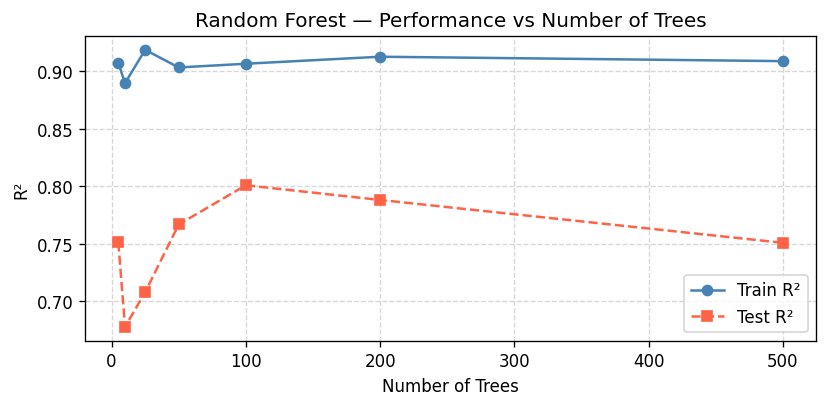

[output not shown]

```python
# ── 4c: Effect of n_estimators on performance ─────────────────

n_tree_vals = [5, 10, 25, 50, 100, 200, 500]
tr_r2s, te_r2s = [], []

for n in n_tree_vals:
    m = RandomForestRegressor(n_estimators=n, random_state=42, n_jobs=-1)
    m.fit(X_tr, y_tr)
    tr_r2s.append(r2_score(y_tr, m.predict(X_tr)))
    te_r2s.append(r2_score(y_te, m.predict(X_te)))

fig, ax = plt.subplots(figsize=(7, 3.5))
ax.plot(n_tree_vals, tr_r2s, 'o-', label='Train R²', color='steelblue')
ax.plot(n_tree_vals, te_r2s, 's--', label='Test R²',  color='tomato')
ax.set_xlabel('Number of Trees'); ax.set_ylabel('R²')
ax.set_title('Random Forest — Performance vs Number of Trees')
ax.legend(); ax.grid(True, linestyle='--', alpha=0.5)
plt.tight_layout(); plt.show()
print('Performance stabilises after ~100 trees. Adding more gives diminishing returns.')
```

## Block 5 · Gradient Boosting (XGBoost / sklearn)

Gradient boosting builds trees **sequentially** — each tree corrects errors from the previous.  
It typically achieves the **highest accuracy** on tabular datasets but needs careful tuning.

| Parameter | What it controls |
| --- | --- |
| `n_estimators` | Number of boosting rounds |
| `learning_rate` | How much each tree contributes (smaller = more robust, needs more trees) |
| `max_depth` | Depth of each tree (deeper = more complex, more risk of overfit) |
| `subsample` | Fraction of rows used per tree (< 1 reduces overfit) |

```python
# ── 5a: Gradient Boosting — sklearn vs XGBoost ─────────────────

gb_sklearn = GradientBoostingRegressor(
    n_estimators=200, learning_rate=0.05, max_depth=3,
    subsample=0.8, random_state=42)

res_gb, pred_gb = evaluate('GradBoost (sklearn)', gb_sklearn, X_tr, X_te, y_tr, y_te)

results_boost = [res_gb]

if XGB_OK:
    xgb_model = XGBRegressor(
        n_estimators=200, learning_rate=0.05, max_depth=3,
        subsample=0.8, colsample_bytree=0.8,
        random_state=42, verbosity=0)
    res_xgb, pred_xgb = evaluate('XGBoost', xgb_model, X_tr, X_te, y_tr, y_te)
    results_boost.append(res_xgb)

display(pd.DataFrame(results_boost))
```

|  | Model | R2_train | R2_test | MAE_test | RMSE_test |
| --- | --- | --- | --- | --- | --- |
| 0 | GradBoost (sklearn) | 1.0 | 0.734 | 13.01 | 20.42 |
| 1 | XGBoost | 1.0 | 0.876 | 10.24 | 13.94 |

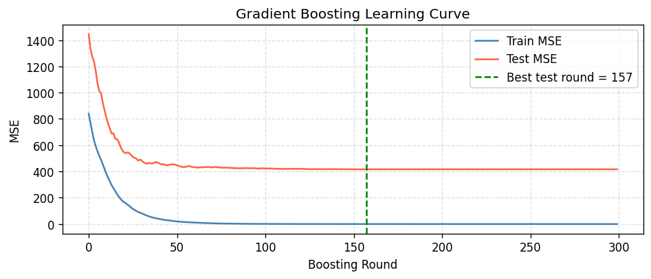

```
Test MSE bottoms out at round 157 — set n_estimators to this.
```

```python
# ── 5b: Learning curve — training loss vs boosting rounds ──────

# Staged predictions let us watch training and test loss at each round
gb_trace = GradientBoostingRegressor(
    n_estimators=300, learning_rate=0.05, max_depth=3,
    subsample=0.8, random_state=42)
gb_trace.fit(X_tr, y_tr)

train_err = [mean_squared_error(y_tr, pred) for pred in gb_trace.staged_predict(X_tr)]
test_err  = [mean_squared_error(y_te, pred) for pred in gb_trace.staged_predict(X_te)]

fig, ax = plt.subplots(figsize=(8, 3.5))
ax.plot(train_err, label='Train MSE', color='steelblue')
ax.plot(test_err,  label='Test MSE',  color='tomato')
best_round = int(np.argmin(test_err))
ax.axvline(best_round, color='green', linestyle='--',
           label=f'Best test round = {best_round}')
ax.set_xlabel('Boosting Round'); ax.set_ylabel('MSE')
ax.set_title('Gradient Boosting Learning Curve')
ax.legend(); ax.grid(True, linestyle='--', alpha=0.4)
plt.tight_layout(); plt.show()
print(f'Test MSE bottoms out at round {best_round} — set n_estimators to this.')
```

## Block 6 · Cross-Validation — Reliable Performance Estimation

A single train/test split gives one number that depends on which compounds land in the test set by chance.  
**K-fold cross-validation** repeats the split K times and averages the result — much more reliable.

**Rule:** Always report cross-validated performance, not just one test-set R².

```python
# ── 6a: 5-fold and 10-fold CV for all models ──────────────────

models_cv = [
    ('Ridge',          Ridge(alpha=1.0)),
    ('PLS',            PLSRegression(n_components=best_n)),
    ('SVM (RBF)',      SVR(kernel='rbf', C=10, gamma='scale')),
    ('Random Forest',  RandomForestRegressor(n_estimators=200, random_state=42)),
    ('GradBoost',      GradientBoostingRegressor(n_estimators=200, learning_rate=0.05,
                                                  max_depth=3, random_state=42)),
]

cv_rows = []
for name, model in models_cv:
    cv5  = cross_val_score(model, X_scaled, y_IS, cv=5,  scoring='r2')
    cv10 = cross_val_score(model, X_scaled, y_IS, cv=10, scoring='r2')
    cv_rows.append({
        'Model':         name,
        '5-fold mean':   round(cv5.mean(),  3),
        '5-fold std':    round(cv5.std(),   3),
        '10-fold mean':  round(cv10.mean(), 3),
        '10-fold std':   round(cv10.std(),  3),
    })

df_cv = pd.DataFrame(cv_rows)
display(df_cv)
```

```
GradBoost
```

|  | Model | 5-fold mean | 5-fold std | 10-fold mean | 10-fold std |
| --- | --- | --- | --- | --- | --- |
| 0 | Ridge | NaN | NaN | NaN | NaN |
| 1 | PLS | -2.652502e+14 | 5.305005e+14 | -2.439121e+16 | 7.317363e+16 |
| 2 | SVM (RBF) | -2.660000e-01 | 5.680000e-01 | -3.280100e+01 | 8.330100e+01 |
| 3 | Random Forest | 2.340000e-01 | 7.410000e-01 | -1.585100e+01 | 3.746200e+01 |
| 4 | GradBoost | 2.680000e-01 | 7.800000e-01 | -1.213800e+01 | 2.508100e+01 |

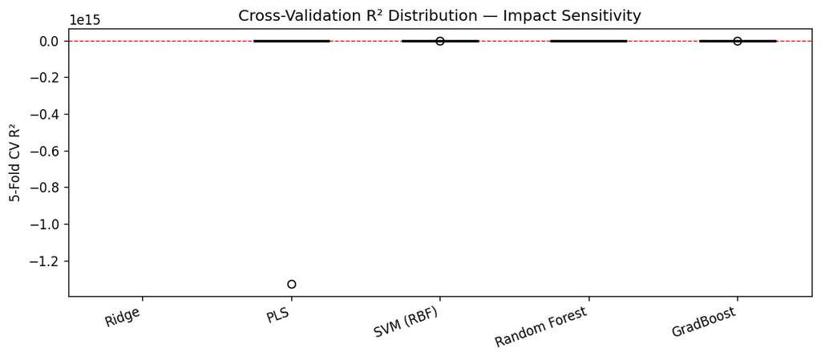

```
Narrow box = consistent across folds.  Wide box = model is sensitive to data split.
```

```python
# ── 6b: Visualise CV fold distribution ────────────────────────

fig, ax = plt.subplots(figsize=(9, 4))
model_names = [r[0] for r in models_cv]

all_cv_scores = []
for name, model in models_cv:
    cv5 = cross_val_score(model, X_scaled, y_IS, cv=5, scoring='r2')
    all_cv_scores.append(cv5)

bp = ax.boxplot(all_cv_scores, labels=model_names, patch_artist=True,
                medianprops=dict(color='black', lw=2))
colors_bp = ['#AED6F1','#A9DFBF','#FAD7A0','#F1948A','#D7BDE2']
for patch, col in zip(bp['boxes'], colors_bp):
    patch.set_facecolor(col)
ax.set_ylabel('5-Fold CV R²')
ax.set_title('Cross-Validation R² Distribution — Impact Sensitivity')
ax.axhline(0, color='red', linestyle='--', linewidth=0.8)
ax.set_xticklabels(model_names, rotation=20, ha='right')
plt.tight_layout(); plt.show()
print('Narrow box = consistent across folds.  Wide box = model is sensitive to data split.')
```

## Block 7 · Hyperparameter Tuning — Grid Search and Random Search

Most models have **hyperparameters** (settings you choose before training).  
Tuning finds the best combination automatically.

| Method | How it works | When to use |
| --- | --- | --- |
| Grid Search | Tries every combination in a predefined grid | Small grids (<100 combos) |
| Random Search | Randomly samples combinations | Large grids — often finds good settings faster |

```python
# ── 7a: Grid search — SVM ─────────────────────────────────────

svm_grid = {
    'C':     [0.1, 1, 10, 50],
    'gamma': ['scale', 0.01, 0.001],
    'kernel':['rbf', 'linear'],
}

gs = GridSearchCV(SVR(), svm_grid, cv=5, scoring='r2', n_jobs=-1, verbose=0)
gs.fit(X_scaled, y_IS)

print('Grid Search — SVM')
print(f'  Best params: {gs.best_params_}')
print(f'  Best CV R²:  {gs.best_score_:.3f}')

# Show top 5 combinations
cv_results = pd.DataFrame(gs.cv_results_)\
               .sort_values('mean_test_score', ascending=False)\
               [['param_C','param_gamma','param_kernel','mean_test_score','std_test_score']]\
               .head(5)
cv_results.columns = ['C','gamma','kernel','mean_R2','std_R2']
display(cv_results)
```

```
Grid Search — SVM
  Best params: {'C': 1, 'gamma': 'scale', 'kernel': 'linear'}
  Best CV R²:  -0.001
```

|  | C | gamma | kernel | mean_R2 | std_R2 |
| --- | --- | --- | --- | --- | --- |
| 7 | 1 | scale | linear | -0.000898 | 0.899174 |
| 9 | 1 | 0.01 | linear | -0.000898 | 0.899174 |
| 11 | 1 | 0.001 | linear | -0.000898 | 0.899174 |
| 3 | 0.1 | 0.01 | linear | -0.044208 | 0.600026 |
| 5 | 0.1 | 0.001 | linear | -0.044208 | 0.600026 |

```
Random Search — Random Forest
  Best params: {'max_depth': 10, 'max_features': 0.5, 'min_samples_leaf': 1, 'min_samples_split': 2, 'n_estimators': 394}
  Best CV R²:  0.308
```

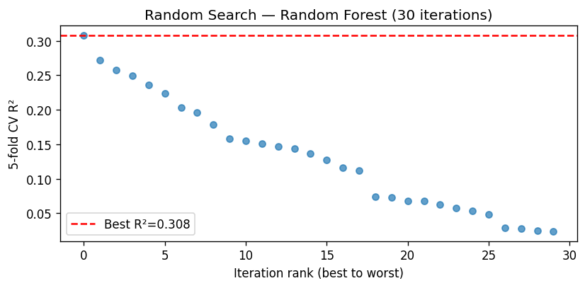

```python
# ── 7b: Random search — Random Forest ─────────────────────────

from scipy.stats import randint, uniform

rf_param_dist = {
    'n_estimators':      randint(50, 400),
    'max_depth':         [None, 3, 5, 8, 10],
    'min_samples_split': randint(2, 10),
    'min_samples_leaf':  randint(1, 5),
    'max_features':      ['sqrt', 'log2', 0.5],
}

rs = RandomizedSearchCV(
    RandomForestRegressor(random_state=42, n_jobs=-1),
    rf_param_dist, n_iter=30, cv=5,
    scoring='r2', random_state=42, n_jobs=-1, verbose=0)
rs.fit(X_scaled, y_IS)

print('Random Search — Random Forest')
print(f'  Best params: {rs.best_params_}')
print(f'  Best CV R²:  {rs.best_score_:.3f}')

# Plot improvement over iterations
rs_df = pd.DataFrame(rs.cv_results_).sort_values('rank_test_score')
fig, ax = plt.subplots(figsize=(7, 3.5))
ax.scatter(range(len(rs_df)), rs_df['mean_test_score'], s=30, alpha=0.7)
ax.axhline(rs.best_score_, color='red', linestyle='--',
           label=f'Best R²={rs.best_score_:.3f}')
ax.set_xlabel('Iteration rank (best to worst)')
ax.set_ylabel('5-fold CV R²')
ax.set_title('Random Search — Random Forest (30 iterations)')
ax.legend(); plt.tight_layout(); plt.show()
```

## Block 8 · Model Comparison Dashboard

Compare all models side-by-side on the same dataset using the same split.  
Use CV R² as the primary metric — not training R².

```python
# ── 8a: Train all models and collect metrics ──────────────────

best_svm = gs.best_estimator_
best_rf  = rs.best_estimator_




final_models = [
    # Change solver to 'svd' or 'sag' to avoid the sym_pos error
    ('Ridge',         Ridge(alpha=1.0, solver='svd')),
    ('PLS',           PLSRegression(n_components=best_n)),
    ('SVM (tuned)',   best_svm),
    ('RF (tuned)',    best_rf),
    ('GradBoost',     GradientBoostingRegressor(n_estimators=200, learning_rate=0.05,
                                                max_depth=3, random_state=42)),
]



dashboard_rows = []
pred_all = {}
for name, model in final_models:
    cv5  = cross_val_score(model, X_scaled, y_IS, cv=5, scoring='r2')
    res, pred = evaluate(name, model, X_tr, X_te, y_tr, y_te)
    res['CV5_mean'] = round(cv5.mean(), 3)
    res['CV5_std']  = round(cv5.std(),  3)
    dashboard_rows.append(res)
    pred_all[name]  = pred

df_dash = pd.DataFrame(dashboard_rows)
display(df_dash)
```

|  | Model | R2_train | R2_test | MAE_test | RMSE_test | CV5_mean | CV5_std |
| --- | --- | --- | --- | --- | --- | --- | --- |
| 0 | Ridge | 0.999 | 0.575 | 16.82 | 25.79 | -4.800000e-02 | 9.490000e-01 |
| 1 | PLS | 0.996 | 0.623 | 16.00 | 24.27 | -2.652502e+14 | 5.305005e+14 |
| 2 | SVM (tuned) | 0.996 | 0.595 | 16.56 | 25.18 | -1.000000e-03 | 8.990000e-01 |
| 3 | RF (tuned) | 0.915 | 0.753 | 12.95 | 19.66 | 3.080000e-01 | 6.790000e-01 |
| 4 | GradBoost | 1.000 | 0.808 | 11.96 | 17.35 | 2.680000e-01 | 7.800000e-01 |

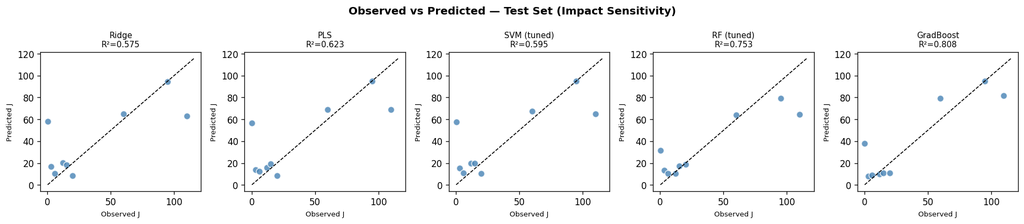

```python
# ── 8b: Obs vs Pred grid for all models ───────────────────────

fig, axes = plt.subplots(1, len(final_models), figsize=(16, 3.5))

for ax, (name, _) in zip(axes, final_models):
    obs_vs_pred(ax, y_te, pred_all[name], name, 'J')

plt.suptitle('Observed vs Predicted — Test Set (Impact Sensitivity)',
             fontsize=12, fontweight='bold')
plt.tight_layout()
plt.show()
```

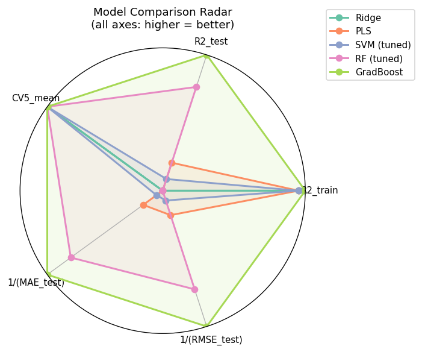

```python
# ── 8c: Radar comparison chart ────────────────────────────────

import matplotlib.patches as mpatches

metrics    = ['R2_train','R2_test','CV5_mean']
inv_metrics= ['MAE_test','RMSE_test']   # lower=better → invert for radar

# Normalise 0-1 for radar
radar_df = df_dash.set_index('Model')[metrics + inv_metrics].copy()
for col in inv_metrics:   # invert so bigger = better
    radar_df[col] = 1 - (radar_df[col] - radar_df[col].min()) / \
                        (radar_df[col].max() - radar_df[col].min() + 1e-9)
for col in metrics:
    radar_df[col] = (radar_df[col] - radar_df[col].min()) / \
                    (radar_df[col].max() - radar_df[col].min() + 1e-9)

all_labels = metrics + [f'1/({m})' for m in inv_metrics]
angles = np.linspace(0, 2*np.pi, len(all_labels), endpoint=False).tolist()
angles += angles[:1]

fig, ax = plt.subplots(figsize=(6, 6), subplot_kw=dict(polar=True))
colors_r = plt.cm.Set2.colors

for idx, (model_name, row) in enumerate(radar_df.iterrows()):
    vals = row.tolist() + row.tolist()[:1]
    ax.plot(angles, vals, 'o-', lw=1.8, color=colors_r[idx], label=model_name)
    ax.fill(angles, vals, alpha=0.1, color=colors_r[idx])

ax.set_thetagrids(np.degrees(angles[:-1]), all_labels, fontsize=9)
ax.set_ylim(0, 1); ax.set_yticks([])
ax.set_title('Model Comparison Radar\n(all axes: higher = better)', fontsize=11, pad=20)
ax.legend(loc='upper right', bbox_to_anchor=(1.4, 1.15), fontsize=9)
plt.tight_layout(); plt.show()
```

## Block 9 · Predict All Properties

Chapter 4 covers five prediction targets.  
Here we train the best model (Random Forest) separately for each property  
and plot all observed-vs-predicted results together.

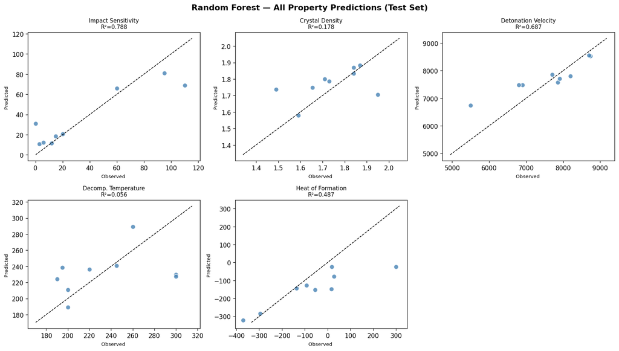

|  | Property | R2_test | MAE_test |
| --- | --- | --- | --- |
| 0 | Impact Sensitivity (J) | 0.788 | 12.31 |
| 1 | Crystal Density (g/cc) | 0.178 | 0.09 |
| 2 | Detonation Velocity (m/s) | 0.687 | 429.04 |
| 3 | Decomp. Temperature (°C) | 0.056 | 32.41 |
| 4 | Heat of Formation (kJ/mol) | 0.487 | 93.03 |

```python
# ── 9a: Train RF for each property ────────────────────────────

targets = {
    'Impact Sensitivity (J)':    y_IS,
    'Crystal Density (g/cc)':    y_rho,
    'Detonation Velocity (m/s)': y_Dv,
    'Decomp. Temperature (°C)':  y_Td,
    'Heat of Formation (kJ/mol)':y_Hf,
}

prop_results = []
fig, axes = plt.subplots(2, 3, figsize=(14, 8))
axes = axes.flatten()

for idx, (label, y_prop) in enumerate(targets.items()):
    Xp_tr, Xp_te, yp_tr, yp_te = train_test_split(
        X_scaled, y_prop, test_size=0.30, random_state=42)

    rf_prop = RandomForestRegressor(n_estimators=200, random_state=42, n_jobs=-1)
    rf_prop.fit(Xp_tr, yp_tr)
    yp_pred = rf_prop.predict(Xp_te)

    r2  = r2_score(yp_te, yp_pred)
    mae = mean_absolute_error(yp_te, yp_pred)
    prop_results.append({'Property': label,
                          'R2_test': round(r2, 3),
                          'MAE_test': round(mae, 2)})

    ax = axes[idx]
    obs_vs_pred(ax, yp_te, yp_pred, label.split('(')[0].strip())

axes[-1].axis('off')   # hide unused 6th subplot
plt.suptitle('Random Forest — All Property Predictions (Test Set)',
             fontsize=13, fontweight='bold')
plt.tight_layout(); plt.show()

display(pd.DataFrame(prop_results))
```

```python
# ── 9b: Kamlet-Jacobs vs ML — detonation velocity ─────────────
# Compare empirical KJ equations with RF predictions

def kamlet_jacobs_D(N, M, Q, rho):
    phi = N * math.sqrt(M * Q)
    return round(1.01 * math.sqrt(phi) * (1 + 1.30*rho) * 1000, 0)

# KJ parameters for the 4 compounds we have data for
kj_known = {
    'TNT':  (0.01987, 50.51, 1080, 1.654),
    'RDX':  (0.02987, 27.67, 1510, 1.820),
    'HMX':  (0.02975, 27.61, 1482, 1.905),
    'PETN': (0.02865, 28.26, 1510, 1.778),
}

comp_rows = []
for cname, (N, M, Q, rho) in kj_known.items():
    idx  = list(names).index(cname)
    rf_d = RandomForestRegressor(n_estimators=200, random_state=42)
    rf_d.fit(X_scaled, y_Dv)
    rf_pred = round(rf_d.predict(X_scaled[[idx]])[0], 0)
    comp_rows.append({
        'Compound':   cname,
        'Experimental': df_meta.loc[df_meta['Name']==cname, 'Dv_ms'].values[0],
        'KJ Estimate':  kamlet_jacobs_D(N, M, Q, rho),
        'RF Predicted': rf_pred,
    })

df_kj_vs_rf = pd.DataFrame(comp_rows)
df_kj_vs_rf['KJ Error %'] = abs(df_kj_vs_rf['KJ Estimate'] - df_kj_vs_rf['Experimental'])\
                              / df_kj_vs_rf['Experimental'] * 100
df_kj_vs_rf['RF Error %'] = abs(df_kj_vs_rf['RF Predicted'] - df_kj_vs_rf['Experimental'])\
                              / df_kj_vs_rf['Experimental'] * 100
df_kj_vs_rf[['KJ Error %','RF Error %']] = df_kj_vs_rf[['KJ Error %','RF Error %']].round(1)

display(df_kj_vs_rf)
```

|  | Compound | Experimental | KJ Estimate | RF Predicted | KJ Error % | RF Error % |
| --- | --- | --- | --- | --- | --- | --- |
| 0 | TNT | 6900 | 6854.0 | 7056.0 | 0.7 | 2.3 |
| 1 | RDX | 8750 | 8400.0 | 8677.0 | 4.0 | 0.8 |
| 2 | HMX | 9110 | 8614.0 | 8926.0 | 5.4 | 2.0 |
| 3 | PETN | 8400 | 8136.0 | 8482.0 | 3.1 | 1.0 |

## Block 10 · Domain of Applicability (DoA)

A QSPR model is only reliable for molecules **similar to its training set**.  
The domain of applicability tells you when NOT to trust a prediction.

Three methods covered:

1. **Leverage (hat values)** — distance from training data centroid in descriptor space
2. **Euclidean distance** to nearest training compound
3. **Prediction interval** — how much the forest's trees disagree

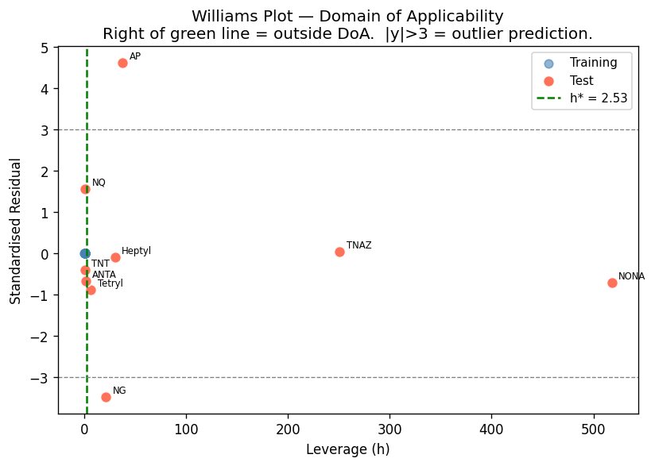

```python
# ── 10a: Leverage method ───────────────────────────────────────
# h = x^T (X^T X)^{-1} x
# Warning threshold: h* = 3(p+1)/n   where p=features, n=train samples

from numpy.linalg import pinv

# Use structural descriptors only for interpretability
struct_idx = [i for i, f in enumerate(feat_names_final)
              if not f.startswith('FP')]
Xs_tr_doa  = X_tr[:, struct_idx]
Xs_te_doa  = X_te[:, struct_idx]
Xs_all_doa = X_scaled[:, struct_idx]

H_matrix = Xs_tr_doa @ pinv(Xs_tr_doa.T @ Xs_tr_doa) @ Xs_tr_doa.T
h_train  = np.diag(H_matrix)

# Leverage for test set
p  = Xs_tr_doa.shape[1]
n  = Xs_tr_doa.shape[0]
h_star = 3 * (p + 1) / n

h_test = np.array([
    float(x @ pinv(Xs_tr_doa.T @ Xs_tr_doa) @ x)
    for x in Xs_te_doa
])

rf_doa = RandomForestRegressor(n_estimators=200, random_state=42)
rf_doa.fit(X_tr, y_tr)
pred_doa = rf_doa.predict(X_te)
std_res  = np.sqrt(mean_squared_error(y_tr, rf_doa.predict(X_tr)))
std_res  = max(std_res, 1e-6)
s_test   = (y_te - pred_doa) / std_res

print(f'Warning threshold h* = {h_star:.3f}')
print(f'Test compounds with h > h*: '
      f'{[n_te[i] for i in range(len(h_test)) if h_test[i] > h_star]}')

# Williams plot: leverage vs standardised residual
fig, ax = plt.subplots(figsize=(7, 5))
ax.scatter(h_train, np.zeros(len(h_train)), s=40, color='steelblue',
           label='Training', alpha=0.6)
ax.scatter(h_test, s_test, s=70, color='tomato',
           label='Test', alpha=0.9, edgecolors='white')
for i, name in enumerate(n_te):
    ax.annotate(name, (h_test[i], s_test[i]),
                textcoords='offset points', xytext=(5, 3), fontsize=7)

ax.axvline(h_star, color='green', linestyle='--', label=f'h* = {h_star:.2f}')
ax.axhline(3,  color='grey',  linestyle='--', linewidth=0.8)
ax.axhline(-3, color='grey',  linestyle='--', linewidth=0.8)
ax.set_xlabel('Leverage (h)')
ax.set_ylabel('Standardised Residual')
ax.set_title('Williams Plot — Domain of Applicability\n'
             'Right of green line = outside DoA.  |y|>3 = outlier prediction.')
ax.legend(fontsize=9)
plt.tight_layout(); plt.show()
```

[output not shown]

```python
# ── 10b: Euclidean distance to nearest training neighbour ──────

from sklearn.metrics import pairwise_distances

dist_matrix = pairwise_distances(X_te, X_tr)
min_dist    = dist_matrix.min(axis=1)   # distance to nearest training compound

# Threshold = 95th percentile of training-set internal distances
train_self_dist = pairwise_distances(X_tr, X_tr)
np.fill_diagonal(train_self_dist, np.nan)
thresh_dist = np.nanpercentile(train_self_dist, 95)

doa_df = pd.DataFrame({
    'Compound':     n_te,
    'Min_dist':     min_dist.round(3),
    'Observed IS':  y_te,
    'Predicted IS': pred_doa.round(1),
    'In DoA':       min_dist < thresh_dist
})

print(f'Distance threshold (95th pct): {thresh_dist:.3f}')
display(doa_df)
```

```
Distance threshold (95th pct): 15.784
```

|  | Compound | Min_dist | Observed IS | Predicted IS | In DoA |
| --- | --- | --- | --- | --- | --- |
| 0 | TNAZ | 11.096 | 12.0 | 11.7 | True |
| 1 | AP | 10.244 | 110.0 | 69.0 | True |
| 2 | Tetryl | 9.654 | 3.0 | 10.9 | True |
| 3 | NONA | 1.260 | 6.0 | 12.3 | True |
| 4 | TNT | 10.203 | 15.0 | 18.6 | True |
| 5 | NQ | 0.000 | 95.0 | 81.1 | True |
| 6 | NG | 1.272 | 0.2 | 31.1 | True |
| 7 | Heptyl | 9.894 | 20.0 | 20.8 | True |
| 8 | ANTA | 11.454 | 60.0 | 66.0 | True |

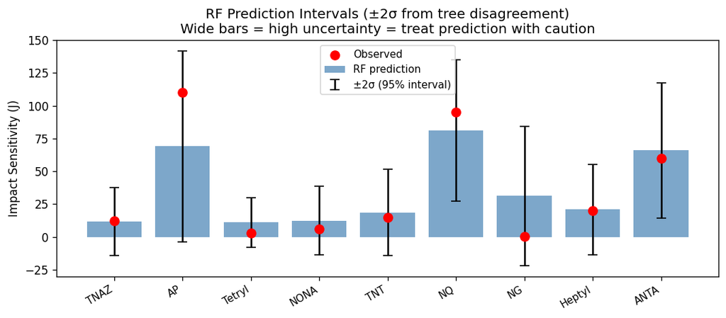

```python
# ── 10c: Prediction interval from RF tree disagreement ─────────
# Each tree in RF gives a prediction; std across trees = confidence

tree_preds = np.array([tree.predict(X_te) for tree in rf_doa.estimators_])
pred_mean  = tree_preds.mean(axis=0)
pred_std   = tree_preds.std(axis=0)

fig, ax = plt.subplots(figsize=(9, 4))
x_pos = np.arange(len(n_te))
ax.bar(x_pos, pred_mean, color='steelblue', alpha=0.7, label='RF prediction')
ax.errorbar(x_pos, pred_mean, yerr=2*pred_std, fmt='none',
            color='black', capsize=4, label='±2σ (95% interval)')
ax.scatter(x_pos, y_te, color='red', zorder=5, s=60, label='Observed')
ax.set_xticks(x_pos)
ax.set_xticklabels(n_te, rotation=30, ha='right', fontsize=9)
ax.set_ylabel('Impact Sensitivity (J)')
ax.set_title('RF Prediction Intervals (±2σ from tree disagreement)\n'
             'Wide bars = high uncertainty = treat prediction with caution')
ax.legend(fontsize=9)
plt.tight_layout(); plt.show()
```

## Summary — What You Learned in Chapter 4

| Block | Concept | Key tool |
| --- | --- | --- |
| 0 | Dataset + feature matrix setup | `rdkit`, `pandas`, `StandardScaler` |
| 1 | MLR, Ridge, Lasso — linear models + coefficients | `LinearRegression`, `LassoCV` |
| 2 | PLS — choose n_components by CV | `PLSRegression`, `cross_val_score` |
| 3 | SVM — kernels + C parameter effect | `SVR`, bias-variance plot |
| 4 | Random Forest — feature importance + n_estimators | `RandomForestRegressor` |
| 5 | Gradient Boosting + learning curve | `GradientBoostingRegressor`, `XGBRegressor` |
| 6 | K-fold cross-validation + boxplots | `cross_val_score`, `KFold` |
| 7 | Hyperparameter tuning — grid + random search | `GridSearchCV`, `RandomizedSearchCV` |
| 8 | Full model comparison dashboard + radar | All models side-by-side |
| 9 | Predict all 5 properties + KJ vs RF comparison | Multi-target RF |
| 10 | Domain of applicability — leverage, distance, intervals | Williams plot, `pairwise_distances` |

**Next →** Chapter 5: High-throughput screening, multiscale modelling, and generative AI.

### References & Tools

- Scikit-learn user guide: https://scikit-learn.org/stable/user_guide.html
- XGBoost documentation: https://xgboost.readthedocs.io
- Kamlet & Jacobs (1968) *J. Chem. Phys.* 48(1) — KJ detonation equations
- Tropsha, A. (2010) Best Practices for QSAR Model Development, Validation and Exploitation, *Mol. Inf.* 29(6)
- Gramatica, P. (2007) Principles of QSAR Modelling, *QSAR Comb. Sci.* 26
- Rice, B.M. and Hare, J.J. (2002) *J. Phys. Chem. A* 106(9) — sensitivity predictors
- Karthikeyan & Vyas *Practical Chemoinformatics*, Springer, 2014